# Principal Components Analysis (PCA)

For DATA50XX by ctong

## Overview

### What is Principal Components Analysis (PCA)?

Principal Components Analysis (PCA) is an unsupervised dimensionality reduction technique commonly used in data analysis and machine learning. PCA transforms a set of possibly correlated variables into a set of uncorrelated variables called principal components. The goal is to capture as much variance in the data as possible using fewer dimensions.

**What does it mean to ‘capture variance’?**

Variance is a measure of how much the values in a dataset differ from the average value. In PCA, capturing variance means finding new axes (principal components) that stretch through the data in the directions where the data points are most spread out.

Principal components are ordered so that the first few retain most of the variation present in all of the original variables. Each component is a linear combination of the original variables (more on this below) and is orthogonal (i.e., uncorrelated) to all other components.

- The **1st principal component** captures the maximum variance in the data.
- The **2nd principal component** is orthogonal to the first and captures the next highest variance.
- The **3rd principal component** is orthogonal to the first and second, and captures the next highest variance, and so on.

By focusing on the directions with the most variance, PCA allows us to summarize the key patterns in the data with fewer variables, often revealing underlying structure that might not be obvious from the original variables alone.

This technique is helpful when working with datasets that have many variables, which may be difficult to visualize or analyze directly.

**PCA is typically used when:**

- The dataset has many variables, and you want to reduce the dimensionality.
- You suspect that some variables are correlated.
- You wish to visualize high-dimensional data.
- You need to remove noise or redundant features before applying machine learning algorithms.

### Sample Use Cases

PCA is widely used in many fields because it helps make sense of complex data and reveals patterns that are otherwise difficult to see. Below are some common and important use cases for PCA:

#### Data Visualization

- **High-dimensional data can be hard to plot and interpret.** PCA is often used to reduce data with many variables down to two or three principal components, which can then be visualized with simple scatterplots.
- **Example:** In biology, gene expression data with thousands of genes can be visualized in a two-dimensional plot using the first two principal components, making it easier to see groups or clusters.

#### Preprocessing for Machine Learning

- **Reduces dimensionality to avoid overfitting.** Many machine learning algorithms work better and are less likely to overfit when the number of input features is reduced.
- **Removes redundancy.** When variables are highly correlated, PCA summarizes them into fewer, uncorrelated principal components, making models simpler and sometimes more accurate.
- **Speeds up computation.** Reducing the number of features makes training faster.
- **Example:** Before applying clustering or classification algorithms, PCA can be used to create a smaller set of input features.

#### Noise Reduction

- **PCA can separate signal from noise.** The first few principal components capture most of the meaningful variation in the data, while later components often capture mostly noise.
- **Example:** In sensor data, after applying PCA, components that mainly represent random noise can be dropped, resulting in a cleaner dataset.

#### Image Compression

- **Images are large sets of highly correlated pixel values.** PCA can be used to compress image data by keeping only the principal components that capture most of the variation.
- **Example:** A grayscale image can be reconstructed with much less data using only a few principal components, saving storage space while retaining most of the important information.

#### Genetics and Bioinformatics

- **Finds patterns in genetic data.** Genetic datasets often involve thousands of variables (such as single-nucleotide polymorphisms). PCA helps to identify major patterns, such as population structure or outlier individuals.
- **Example:** In population genetics, PCA is used to detect and visualize subpopulations based on genetic similarity.

#### Quality Control and Process Monitoring

- **Detects unusual observations in manufacturing or process data.** PCA can be used to monitor multiple measurements at once and quickly spot outliers or abnormal events.
- **Example:** In chemical manufacturing, PCA helps track sensor data to detect when a process goes out of control.

#### Text Data Analysis

- **Reduces dimensions of text data.** In text mining or natural language processing, datasets such as document-term matrices can be very large. PCA can help reduce these to a smaller set of features.
- **Example:** PCA can be used to uncover the main themes or topics in a collection of documents.

PCA is a flexible tool that can be applied wherever you have many variables and need to find structure, simplify your data, or prepare it for further analysis.

## Demo

### PCA in R

**Data:** `iris` dataset (excluding the species label)

**Task:** Identify uncorrelated (orthogonal) principal components to reduce data dimensionality

**Function:** `prcomp` uses a mathematical procedure known as Singular Value Decomposition (SVD) to compute principal components

```r
# Remove the Species column
data(iris)
iris_num <- iris[, 1:4] # remove species labels
iris_scaled <- scale(iris_num)  # Standardize each feature to mean 0, sd = 1

# Run PCA
pca_result <- prcomp(iris_scaled, center = TRUE, scale = TRUE)
summary(pca_result)
```

```
## Importance of components:
##                           PC1    PC2     PC3     PC4
## Standard deviation     1.7084 0.9560 0.38309 0.14393
## Proportion of Variance 0.7296 0.2285 0.03669 0.00518
## Cumulative Proportion  0.7296 0.9581 0.99482 1.00000
```

- **Standard deviations:** The square roots of the eigenvalues.
- **Proportion of Variance:** The fraction of the total variance explained by each principal component.
- **Cumulative Proportion:** The cumulative variance explained as you add more components.

### Interpreting Principal Components

Each principal component is a **linear combination** of the original variables. This means that every principal component is created by multiplying each original variable by a number called a “loading,” and then adding these up.

- The **loadings** indicate how much weight each original variable has in the principal component. Loadings are also referred to as eigenvectors or coefficients.
- For example, PC1 = (loading₁ × Variable₁) + (loading₂ × Variable₂) + …
- A **high loading** (positive or negative) means that variable contributes a lot to that component.
- By examining the loadings, you can interpret what each principal component represents. For example, you will see that PC2 has large loadings for “Sepal.Length” and “Sepal.Width,” then PC2 mostly captures variation in sepal size.

```r
# View the loadings
pca_result$rotation
```

```
##                     PC1         PC2        PC3        PC4
## Sepal.Length  0.5210659 -0.37741762  0.7195664  0.2612863
## Sepal.Width  -0.2693474 -0.92329566 -0.2443818 -0.1235096
## Petal.Length  0.5804131 -0.02449161 -0.1421264 -0.8014492
## Petal.Width   0.5648565 -0.06694199 -0.6342727  0.5235971
```

**Interpretation example:**

If `Petal.Length` has a high positive loading for PC1, then increases in `Petal.Length` will cause higher values of PC1. If a variable has a negative loading, higher values of that variable will move the principal component in the opposite direction.

Understanding the loadings helps you explain what each principal component is capturing from your original data.

### Visualize the Principal Components with a Biplot

A biplot is a special type of plot that shows both the observations (data points) and the original variables on the same plot, based on the first two principal components. The observations are plotted as points, and the original variables are shown as arrows. The direction and length of each arrow indicate how strongly each variable influences the principal components.

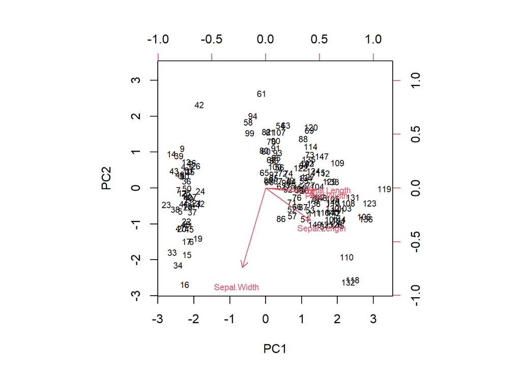

```r
# Biplot of the first two principal components
biplot(pca_result, scale = 0, cex = 0.7)
```

- **Points** represent individual observations (for example, individual flowers in the iris dataset). Cluster of points may indicate subgroups in the data.
- **Arrows** represent the loadings of each variable on the principal components plotted.
  - **Longer arrow** means a variable contributes strongly to the components.
  - **The direction** of an arrow shows how the variable relates to the components. If an arrow points strongly in the direction of PC1, that variable contributes a lot to PC1.

**Correlatons between original variables?**  
- Variables with arrows that point in the similar directions are positively correlated.  
- Variables with arrows pointing in opposite directions are negatively correlated.  
- Variables with arrows at right angles (90 degrees) to each other are not correlated.

### Visualize the Explained Variance

A scree plot shows how much variance each principal component explains.

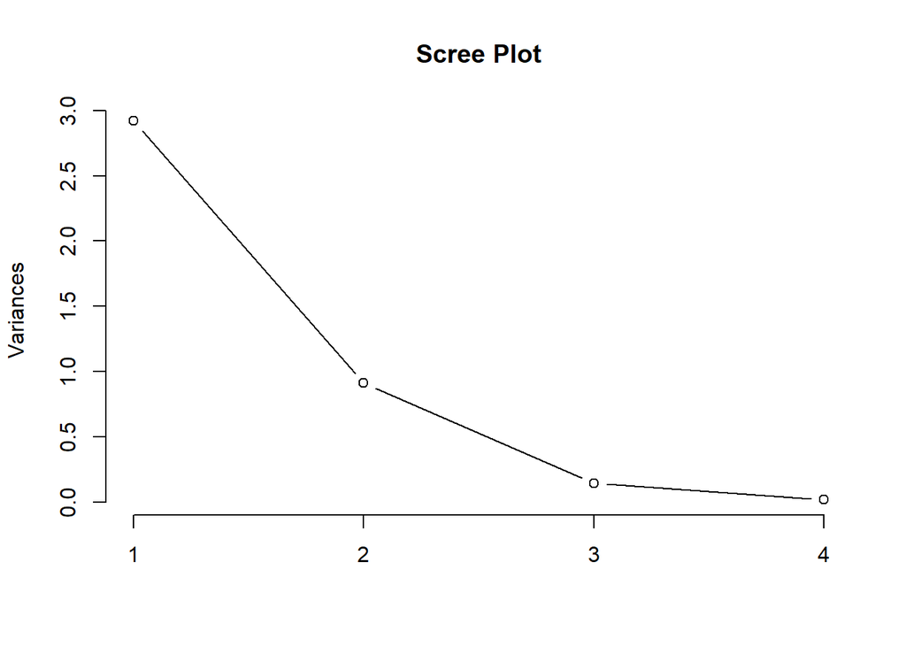

```r
# Scree plot
plot(pca_result, type = "l", main = "Scree Plot")
```

Alternatively, use a bar plot:

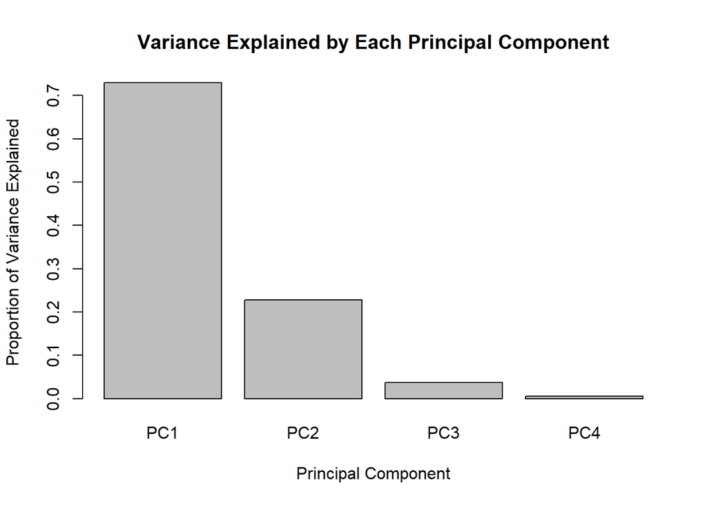

```r
# Bar plot of explained variance
explained_var <- pca_result$sdev^2 / sum(pca_result$sdev^2)
barplot(explained_var, names.arg = paste0("PC", 1:length(explained_var)),
        ylab = "Proportion of Variance Explained", xlab = "Principal Component",
        main = "Variance Explained by Each Principal Component")
```

### Visualize the Observations in Component Space

You can visualize how the observations are spread along the first two principal components.

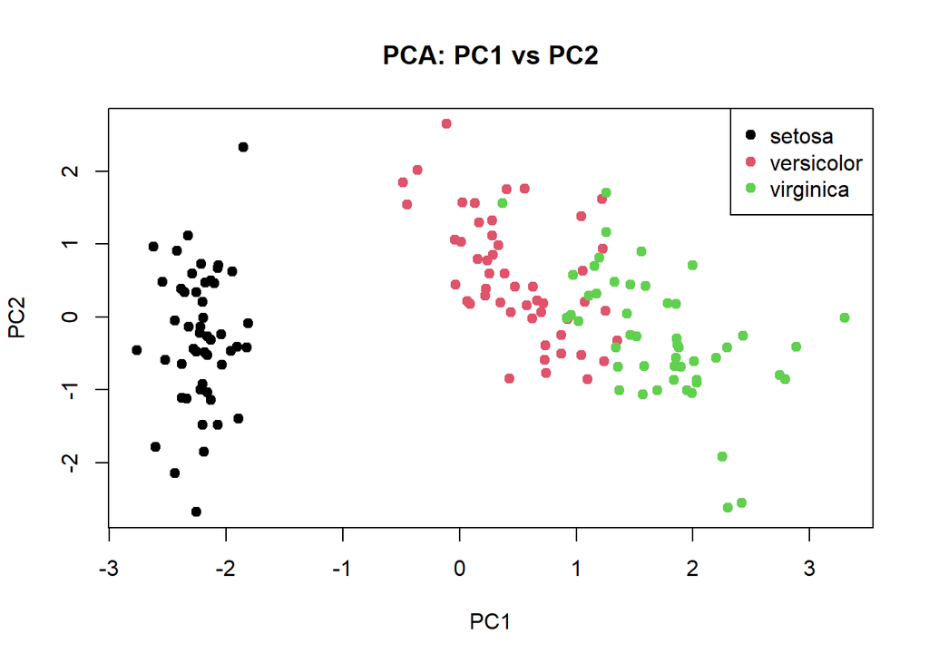

```r
# Plot the first two principal components
plot(pca_result$x[, 1], pca_result$x[, 2],
     xlab = "PC1", ylab = "PC2", main = "PCA: PC1 vs PC2")
# Add species labels with colors
points(pca_result$x[, 1], pca_result$x[, 2],
       col = as.numeric(iris$Species), pch = 19)
legend("topright", legend = levels(iris$Species), col = 1:3, pch = 19)
```

## Summary

### Principal Component Analysis

- PCA is a powerful tool for reducing dimensionality and uncovering structure in high-dimensional data.
- It is widely used for visualization, noise reduction, and as a preprocessing step for machine learning.
- Always interpret the results with care and consider whether the principal components make sense for your data and your goals.

### Limitations and Considerations

- PCA assumes that the directions with the largest variances are the most important.
- PCA is sensitive to the scale of the variables, so always standardize.
- The new components may not always have a meaningful real-world interpretation.
- PCA works only with numeric data.
- **PCA is often confused with Exploratory Factor Analysis (EFA):**
  - **PCA** is a technique for reducing the dimensionality of data by creating new variables (principal components) that are linear combinations of the originals. The primary goal of PCA is to explain the **total variance** in the data as efficiently as possible.
  - **EFA** seeks to discover underlying “factors” that can explain why the observed variables are related. EFA aims to explain the **covariance (shared variation)** between variables by modeling latent (unobserved) factors that influence groups of variables together. EFA is based on a statistical model that includes both common factors and unique factors (error), while PCA is a purely mathematical transformation.